# word2vec

Jilung Hsieh

2022-05-02

# wordVectors

- https://github.com/bmschmidt/wordVectors
- We will use a `wordVector` package, installing by `devtools::install_github("bmschmidt/wordVectors")`
- `rword2vec` is another packages for building word2vec model

Raw document -> doc_id - word -> tokenized (text_data.txt) -> wordVectors::train_word2vec (vec.bin)

vec.bin -> word2vec | model <- read.word2vec(“vec.bin”) | terms <- summary(model, “vocabulary”) | embedding <- as.matrix(model)

```r
knitr::opts_chunk$set(echo = TRUE)
```

```r
load("data/s3_watched.rda")
Sys.setlocale(locale="zh_TW.UTF-8")
```

```
## [1] "zh_TW.UTF-8/zh_TW.UTF-8/zh_TW.UTF-8/C/zh_TW.UTF-8/zh_TW.UTF-8"
```

```r
library(tidyverse)
library(stringr)
library(tidytext)
library(jiebaR)
library(lubridate)
# devtools::install_github("bmschmidt/wordVectors")
library(wordVectors)
library(word2vec)
library(tidyr)
options(scipen = 999)
```

```r
library(jiebaR)
stopWords <- readRDS("data/stopWords.rds")
segment_not <- c("爸爸", "爸媽", "新手")
watched <- c("爸爸","父親","老公","先生","丈夫","奶爸",
             "寶爸","隊友","爹地","爸比","把拔","把鼻",
             "老爸","另一半","拔拔", "孩子的爸","孩子爸",
             "爸拔","他爸","她爸","新手爸","版爸", "板爸",
             "我家男人","當爸的","腦公","阿爸","人父",
             "孩子的爹","孩子爹","老爹","外子","拔比",
             "爸鼻","爸把","爸逼","爸咪","把爸","拔爸",
             "爹低","帥爸","準爸","小孩爸","親爸","神爸",
             "宅爸","瓶餵爸","寶寶的爸","孩的爸","女兒的爸")

reserved <- c("神隊友", "豬隊友", "好隊友", "好先生", "好爸爸", "好老公")

watched <- c(watched, reserved)

watched.str <- paste0(watched, collapse = "|")


reserved <- c("神隊友", "豬隊友", "好隊友", "好先生", "好爸爸", "好老公")

cutter <- worker()
tagger <- worker("tag")
new_user_word(cutter, segment_not)
```

```
## [1] TRUE
```

```r
new_user_word(cutter, watched)
```

```
## [1] TRUE
```

```r
new_user_word(tagger, segment_not)
```

```
## [1] TRUE
```

```r
new_user_word(tagger, watched)
```

```
## [1] TRUE
```

# Tokenization

```r
unnested.df <- s3.watched %>%
    filter(str_detect(sentence, "隊友")) %>%
    mutate(word = purrr::map(s3, function(x)segment(x, cutter))) %>%
    unnest(word) %>%
    anti_join(stopWords) %>%
    filter(!str_detect(word, "[a-zA-Z0-9]+")) %>%
    filter(!is.na(word)) %>%
    group_by(word) %>%
    filter(n() > 5) %>%
    ungroup() %>%
    filter(nchar(word) > 1)
id2text <- unnested.df %>%
    select(doc_id = sid, word) %>%
    group_by(doc_id) %>%
    summarise(text = paste(word, collapse = " ")) %>%
    ungroup()

id2text %>%
    .$text %>%
    write("text_data.txt")
```

# EMBEDDINGS

## word2vec::Training Model

- Once you trained a model, the model can be saved to a `vec.bin` binary file. If you need to use the model again, you needn’t rebuild a model, just load the model by `read.vectors(file_name)`.

```r
model = train_word2vec("text_data.txt", output="vec.bin",
                       threads = 4, vectors = 300,
                       window =5, min_count = 12,
                       iter=10, force=TRUE)
```

```
## Starting training using file /Users/jirlong/Dropbox/Programming/R/SMOA/text_data.txt
## 100K
Vocab size: 1627
## Words in train file: 99494
```

```
## Filename ends with .bin, so reading in binary format
```

```
## Reading a word2vec binary file of 1627 rows and 300 columns
```

```r
# model = read.vectors("vec.bin")
```

# PLOTTING

## Plot by wordVectors

- `plot(model)` needs `tsne` package (`install.packages("tsne")`).
- Now we still has 300 variables, if we want to plot words on a 2-d plane, we need to reduce the dimension of it to 2-dimension. We use **t-sne** here for dimension reduction.
- Results are scaled down to 2 dimension by t-SNE.
- https://www.codeproject.com/Tips/788739/Visualization-of-High-Dimensional-Data-using-t-SNE
- (option) plotting to a png file: Adding `png('2.png',width = 1500,height = 1500,res=150)` before `plot()`, then adding `dev.off()` after `plot()` to close the plotting target.

**It only plots the first 300 vocabularies, without clear rules**

```
## Attempting to use T-SNE to plot the vector representation
```

```
## Cancel if this is taking too long
```

```
## Or run 'install.packages' tsne if you don't have it.
```

```
## sigma summary: Min. : 0.492551842859043 |1st Qu. : 0.586598470198111 |Median : 0.614351559101736 |Mean : 0.623112594655984 |3rd Qu. : 0.648164165761979 |Max. : 0.954420275564588 |
```

[output not shown]

```
## Epoch: Iteration #200 error is: 1.86320825467817
```

```
## Epoch: Iteration #300 error is: 1.59873131987766
```

```
## Epoch: Iteration #400 error is: 1.53597291386491
```

[output not shown]

```
## Epoch: Iteration #600 error is: 1.46253617939688
```

```
## Epoch: Iteration #700 error is: 1.45220533113354
```

```
## Epoch: Iteration #800 error is: 1.44975538998119
```

[output not shown]

```
## Epoch: Iteration #1000 error is: 1.4489991185913
```

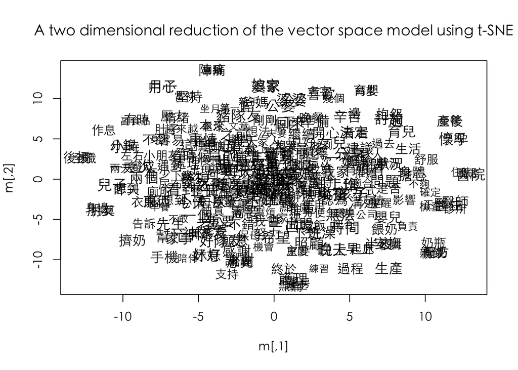

```r
# install.packages("tsne")
# library(Rtsne)
# library(tsne)

par(family="STKaiti")
par(family="Heiti TC Light")
plot(model, method = "tsne")
```